# Assignment 4 - Aquaculture

Gabrielle

2022-11-09

QUESTION (1): Is the relationship of fish growth to protein concentration in the feed the same for each species?

- If the relationship of fish growth to protein concentration in the feed is NOT the same for each species …

QUESTION (2): What is the formula to predict the average growth for different concentrations of protein for each species.

Of note:

- the starting mass:
  - 300 g for juvenile Salmo salar
  - 300 g for Oncorhynchus mykiss
  - 150 g for juvenile Oreochromis niloticus
- the fish were monitored in individual 25 liter holding tanks with flow through water systems for 7 days
- all fish survived the study except one (the Salmo salar individual fed a zero protein diet died after 4 days)

#### Here is a photo of a Juvenile Salmo Salar

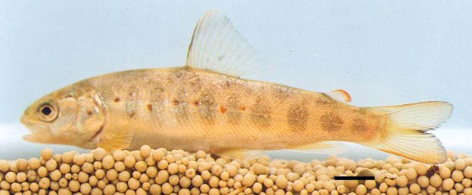

##### Load in the data + clean it:

- Three species of fish
- The fish growth (g/day) for different concentrations of protein feed (kcal/pellet)

```r
fish_growth <- read_csv(here("data","fish_growth.csv"))

# use janitor() and clean up the names
fish <- fish_growth %>% clean_names()
```

##### Scatterplot of the data to visually inpect it:

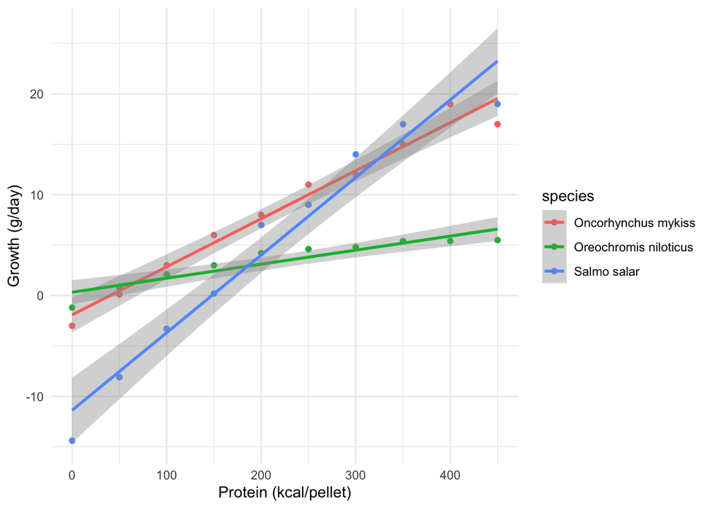

Figure 1. Scatterplot of the relationship between each species’ amount of protein received and their subsequent growth.

```r
fish_scatter <- ggplot(fish, aes(x = protein, y = growth, color = species)) +
  geom_point() +
  geom_smooth(method = "lm") +
  labs(x = "Protein (kcal/pellet)", y = "Growth (g/day)") +
  theme_minimal()

fish_scatter
```

From this scatterplot, we can see that there is a linear relationship between protein and the growth of the fish.

Also, we can double check the strength of this relationship by analyzing the Pearson’s correlation. For this data, the correlation between protein and the growth of the fish is: cor = 0.825091 This means that there is a substantial positive correlation between the amount of protein received and the growth of the fish.

```r
fish$protein <- as.numeric(fish$protein)
fish$growth <- as.numeric(fish$growth)
summary(fish)

cor.test(fish$protein, fish$growth, method = "pearson")
```

#### Now, we will investigate whether there is a different effect for the different species through creating a suite of models

```r
m_0 <- lm(growth ~ 1, data=fish) # mean only model

m_1a <- lm(growth ~ protein, data=fish) # Simple linear regression

m_1b <- lm(growth ~ species, data=fish) # Simple linear regression

m_1c <- lm(growth ~ species + protein, data=fish) # Simple linear regression

m_1d <- lm(growth ~ species * protein, data=fish) # Simple linear regression
# need a constant in the interaction term; that is why we keep the "species*protein" so that the reference fish has a value

m_2a <- lm(growth ~ -1 + protein + I(protein^2), data=fish) # 2nd degree polynomial no constant (intercept)
## I = "as is" command
## run a command without actually changing or adding a variable to the data set

m_2a <- lm(growth ~ -1 + protein + I(protein^2), data=fish)

m_2b <- lm(growth ~ protein + I(protein^2), data=fish)

m_3 <- lm(growth ~ protein + I(protein^2) + I(protein^3), data=fish)


BIC_list <- c(BIC(m_0), BIC(m_1a), BIC(m_1b), BIC(m_1c), BIC(m_1d), BIC(m_2a), BIC(m_2b), BIC(m_3))

model_output <-rbind(data.frame(glance(m_0)),data.frame(glance(m_1a)),data.frame(glance(m_1b)),data.frame(glance(m_1c)),data.frame(glance(m_1d)),data.frame(glance(m_2a)),data.frame(glance(m_2b)), data.frame(glance(m_3))) %>% select(BIC)

model_output <- mutate(model_output, delta.BIC = BIC-min(BIC_list))
model_output$model<-c("Model 0","Model 1a","Model 1b","Model 1c","Model 1d", "Model 2a","Model 2b", "Model 3")
model_output<-model_output[,c("model", "BIC", "delta.BIC" )]


kable(model_output, format = "markdown", digits = 3, caption = "BIC, and Delta.BIC for the IDF models. Delta BIC > 7 indicates models that should be dismissed from further consideration.")
```

BIC, and Delta.BIC for the IDF models. Delta BIC > 7 indicates models that should be dismissed from further consideration.

| model | BIC | delta.BIC |
| --- | --- | --- |
| Model 0 | 217.008 | 84.981 |
| Model 1a | 186.153 | 54.126 |
| Model 1b | 221.506 | 89.479 |
| Model 1c | 185.054 | 53.027 |
| Model 1d | 132.027 | 0.000 |
| Model 2a | 192.585 | 60.558 |
| Model 2b | 187.592 | 55.565 |
| Model 3 | 190.939 | 58.912 |

Model 1d has the lowest BIC value (132.027) of all the models, so it is the best fitting model. It is showing the interaction between the species and the protein given, and the effect on growth of the fish. We considered more flexible quadratic models, but they’re not performing well, and therefore we did not select to move forward with them.

```r
# we may want to merge data and select only certain model statistics.
# here is a way to manipulate the data to get a table

model_output_a <-rbind(data.frame(glance(m_0)),data.frame(glance(m_1a)),data.frame(glance(m_1b)),data.frame(glance(m_1c)),data.frame(glance(m_1d)),data.frame(glance(m_2a)),data.frame(glance(m_2b)), data.frame(glance(m_3))) %>% select(adj.r.squared, BIC)

model_output_a

model_output_b <- mutate(model_output_a, delta.BIC = BIC-min(BIC_list))

model_output_b

# add a column that labels each model within the table!
model_output_b$model <- c("Model 0", "Model 1a", "Model 1b", "Model 1c", "Model 1d", "Model 2a,", "Model 2b", "Model 3")

model_output_b

# rearrange the order of the columns
model_output_b <- model_output_b[,c("model", "adj.r.squared", "BIC", "delta.BIC")]
model_output_b

# even though adj.r.squared is a frequentist term, it is still informative

kable(model_output_b, format = "markdown", digits = 3, caption = "R-Squared Adjusted, BIC, and delta BIC for the fish models. Delta BIC >7 indicates models that should be dismissed from further consideration.")
```

```r
m_1d <- lm(growth ~ species * protein, data=fish) # Simple linear regression

m_1d_out <- summary(m_1d)
m_1d_out
```

[output not shown]

#### The model equation:

g = -1.92 + 0.05(protein) + 2.25(Sp.NIT) - 9.47(AS) - 0.034(Pro * Sp.NIT) + 0.03(protein * AS)

#### The equations for each species using Model 1d:

The equation for rainbow trout (the reference species) g = -1.92 + 0.05(protein)

The equation for Salmo salar g = -1.92 + 0.05(protein) - 9.47 + 0.03(protein)

COMBINE FACTORS g = -11.39 + 0.08(protein)

#### Figure for the best fitting model:

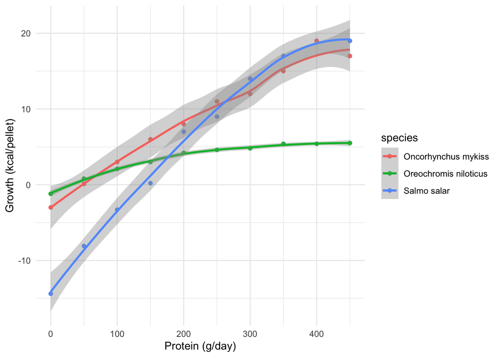

```r
m_1d <- lm(growth ~ species * protein, data=fish)


fig_m1d <- ggplot(fish, aes(x = protein, y = growth, color = species)) +
  geom_point() +
  geom_smooth() +
  labs(x = "Protein (g/day)", y = "Growth (kcal/pellet)") +
  theme_minimal() +
  stat_smooth(method = "lm", formula = lm(growth ~ species * protein, data=fish), se = FALSE)

fig_m1d
```

We have deliberately chosen to keep the intercept for these models. Growth cannot be negative, so we don’t have much reason to force the intercept through zero. However, we do observe that two of the fish species start to plateau as they approach 20 g/day of protein. Here we hypothesize that at some point, the fish can’t take in any more protein. As for the fish that was withheld protein, and therefore, starved, we will explore this data as outlier. In the following analysis, we eliminate the data for Salmo Salar, re-run the model, and note any changes (we expect Oncorhynchus mykiss and Oreochromis niloticus should stay the same).

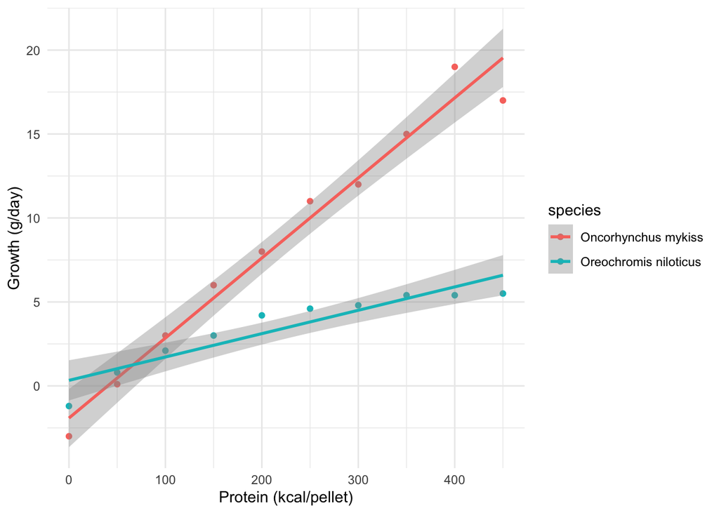

```r
twofish_growth <- read_csv(here("data","fish_growth.csv"))

# use janitor() and clean up the names
twofish <- fish_growth %>% clean_names() %>% filter(species == "Oreochromis niloticus" | species == "Oncorhynchus mykiss")

##### Scatterplot of the data to visually inpect it:
fish_scatter_2 <- ggplot(twofish, aes(x = protein, y = growth, color = species)) +
  geom_point() +
  geom_smooth(method = "lm") +
  labs(x = "Protein (kcal/pellet)", y = "Growth (g/day)") +
  theme_minimal()

fish_scatter_2
```

#### Models run without the starved fish

```r
m_0_two <- lm(growth ~ 1, data=twofish) # mean only model

m_1a_two <- lm(growth ~ protein, data=twofish) # Simple linear regression

m_1b_two <- lm(growth ~ species, data=twofish) # Simple linear regression

m_1c_two <- lm(growth ~ species + protein, data=twofish) # Simple linear regression

m_1d_two <- lm(growth ~ species * protein, data=twofish) # Simple linear regression
# need a constant in the interaction term; that is why we keep the "species*protein" so that the reference fish has a value

m_2a_two <- lm(growth ~ -1 + protein + I(protein^2), data=twofish) # 2nd degree polynomial no constant (intercept)
## I = "as is" command
## run a command without actually changing or adding a variable to the data set

m_2a_two <- lm(growth ~ -1 + protein + I(protein^2), data=twofish)

m_2b_two <- lm(growth ~ protein + I(protein^2), data=twofish)

m_3_two <- lm(growth ~ protein + I(protein^2) + I(protein^3), data=twofish)


BIC_list <- c(BIC(m_0_two), BIC(m_1a_two), BIC(m_1b_two), BIC(m_1c_two), BIC(m_1d_two), BIC(m_2a_two), BIC(m_2b_two), BIC(m_3_two))

model_output_two <-rbind(data.frame(glance(m_0_two)),data.frame(glance(m_1a_two)),data.frame(glance(m_1b_two)),data.frame(glance(m_1c_two)),data.frame(glance(m_1d_two)),data.frame(glance(m_2a_two)),data.frame(glance(m_2b_two)), data.frame(glance(m_3_two))) %>% select(BIC)

model_output_two <- mutate(model_output_two, delta.BIC = BIC-min(BIC_list))
model_output_two$model<-c("Model 0","Model 1a","Model 1b","Model 1c","Model 1d", "Model 2a","Model 2b", "Model 3")
model_output_two<-model_output_two[,c("model", "BIC", "delta.BIC" )]


kable(model_output_two, format = "markdown", digits = 3, caption = "BIC, and Delta.BIC for the IDF models. Delta BIC > 7 indicates models that should be dismissed from further consideration.")
```

[output not shown]

Model 1d still has the lowest BIC value, even when taking out the starved fish.

```r
# we may want to merge data and select only certain model statistics.
# here is a way to manipulate the data to get a table

model_output_a_two <-rbind(data.frame(glance(m_0_two)),data.frame(glance(m_1a_two)),data.frame(glance(m_1b_two)),data.frame(glance(m_1c_two)),data.frame(glance(m_1d_two)),data.frame(glance(m_2a_two)),data.frame(glance(m_2b_two)), data.frame(glance(m_3_two))) %>% select(adj.r.squared, BIC)

model_output_a_two

model_output_b_two <- mutate(model_output_a_two, delta.BIC = BIC-min(BIC_list))

model_output_b_two

# add a column that labels each model within the table!
model_output_b_two$model <- c("Model 0", "Model 1a", "Model 1b", "Model 1c", "Model 1d", "Model 2a,", "Model 2b", "Model 3")

model_output_b_two

# rearrange the order of the columns
model_output_b_two <- model_output_b_two[,c("model", "adj.r.squared", "BIC", "delta.BIC")]
model_output_b_two

# even though adj.r.squared is a frequentist term, it is still informative

kable(model_output_b_two, format = "markdown", digits = 3, caption = "R-Squared Adjusted, BIC, and delta BIC for the fish models WITHOUT the starved fish (Salmo salar). Delta BIC >7 indicates models that should be dismissed from further consideration.")
```

Checking for outliers with single linear regression models

```r
# use janitor() and clean up the names
salmo <- fish_growth %>% clean_names() %>% filter(species == "Salmo salar")

oreo <- fish_growth %>% clean_names() %>% filter(species == "Oreochromis niloticus")

onco <- fish_growth %>% clean_names() %>% filter(species == "Oncorhynchus mykiss")

# Salmo salar
model_salmo <- lm(growth ~ protein, data = salmo)

summary(model_salmo)

# Oncorhynchus mykiss
model_oreo <- lm(growth ~ protein, data = oreo)

summary(model_oreo)

# Oreochromis niloticus
model_onco <- lm(growth ~ protein, data = onco)

summary(model_onco)

# the command "plot(model_salmo)" "plot(model_oreo)" "plot(model_onco)" is showing the residuals versus fitted
```

Therefore, given the above rational, we don’t think there is enough motivation to take the potential outliers out.

FINAL ANSWER:

#### The formula to predict the average growth for different concentrations of protein for each species. is:

g = -1.92 + 0.05(protein) + 2.25(Sp.NIT) - 9.47(AS) - 0.034(Pro * Sp.NIT) + 0.03(protein * AS)

#### The equation for rainbow trout (the reference species):

g = -1.92 + 0.05(protein)

#### The equation for Salmo salar:

g = -11.39 + 0.08(protein)

Concerns: there are very few data, one fish was not fed, it is unclear what the the fish were “monitored” for while in individual 25 liter holding tanks with flow through water systems for 7 days, and it is unclear why 7 days was selected.

Caveats: This data and conclusion is applicable for this sample population, however it cannot be extrapolated to other fish in other settings that differ from this one. Other sources of protein might play a role in the growth potential of fish, in addition to water temperature, time of feeding, crowding of the tank/competition for food, among many other factors.